# Background variables

This notebook will have an overview of Background variables

File names (The number stands for the variable number in each .csv, not including famID): vocabulary.csv WGS_Background_all_v1.csv 134 WGS_Background_baby_V1_14.07.21.csv 38 WGS_Background_environment_V1_14.07.21.csv 19 WGS_Background_family_V1_14.07.21.csv 10 WGS_Background_father_V1_14.07.21.csv 20 WGS_Background_mother_V1_14.07.21.csv 44 WGS_Background_partner_V1_14.07.21.csv 3 total 134

Some basic info: Family number: 90 Type: ID 1 categorical 29 Bool 79 int 24 total 133

#Data valid test The code below is not longer need to run. skip to #Data explore part.

Load files

```r
vocabulary <- read.csv("vocabulary.csv") #note: somehow the original vocabulary.csv have some error: the name of the first column will turn to garbled code.
#You need to use "save as" function in "file" to resave it as .csv
#Here the "vocabulary.csv" is the new one and I deleted the original one.
WGS_Background_all <- read.csv("WGS_Background_all_v1.csv")
```

There seems something wrong with the number of variables between vocabulary(133 include famID) and WB_all(135 include famID) Let’s find out the variables not in vocabulary

```r
var_vocab <- vocabulary %>% select(Variable) %>% pull()
var_all <- WGS_Background_all %>% names()

for (item in var_all) {
  if (!(item %in% var_vocab)) {
    print(item)
  }
}
```

```
[1] "familly_NbSiblings"
[1] "m_HadAllergyDisease"
```

Despite them, we can still output the overview

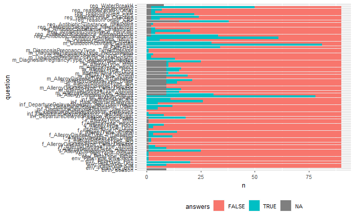

Something weird here. some variable like f_HadAllergyDisease should be categorical variable containing Yes and No, yet was noted as bool and other boolean variable such as inf_Gestational_ageW should be int.

The vocabulary.csv should be corrected. Some boolean variables filled with Yes/No are transfered into TRUE/FALSE.

#Data explore Now let’s redo the steps above to take an overview

Load files

```r
vocabulary <- read.csv("vocabulary.csv")
WGS_Background_all <- read.csv("WGS_Background_all_v1.csv")
```

Overview of cata and bool variables

[figure not shown]

```r
#First, the categorical
var_categ <- vocabulary %>% filter(Type=="categorical") %>% select(Variable) %>% pull()

WB_all_categ <- WGS_Background_all %>% select(Family_ID, any_of(var_categ))
WB_all_categ <- data.frame(lapply(WB_all_categ, as.character))
WB_all_categ_long <- WB_all_categ %>% pivot_longer(!Family_ID, names_to = "question", values_to = "answers")
WB_all_categ_counts <- WB_all_categ_long %>% group_by(question, answers) %>% tally()

p_all_categ <- WB_all_categ_counts %>% ggplot(aes(x=question, y=n, fill=answers)) +
  geom_bar(stat = "identity") +
  coord_flip() +
  theme(legend.position = "bottom",
        text=element_text(size=10))
p_all_categ
```

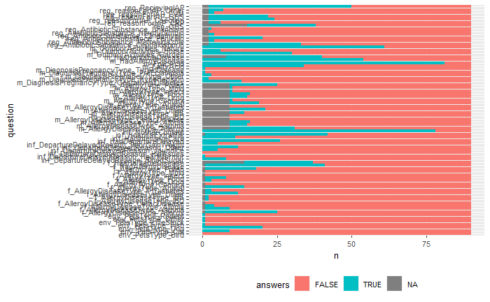

```r
#And the Bool
var_Bool <- vocabulary %>% filter(Type=="Bool") %>% select(Variable) %>% pull()

WB_all_Bool <- WGS_Background_all %>% select(Family_ID, any_of(var_Bool))
WB_all_Bool <-  data.frame(lapply(WB_all_Bool, as.character))
WB_all_Bool_long <- WB_all_Bool %>% pivot_longer(!Family_ID, names_to = "question", values_to = "answers")
WB_all_Bool_counts <- WB_all_Bool_long %>% group_by(question, answers) %>% tally()
WB_all_Bool_counts <- WB_all_Bool_counts %>% filter(answers %in% c("TRUE", "FALSE") | is.na(answers))

p_all_Bool <- WB_all_Bool_counts %>% ggplot(aes(x=question, y=n, fill=answers)) +
  geom_bar(stat = "identity") +
  coord_flip() +
  theme(legend.position = "bottom",
        text=element_text(size=10))
p_all_Bool
```

Some boolean variables only contain FALSE & NA, which is not needed for later analysis. These varibales are:

```r
num_useless=0
ul_bool <- c()
for (item in var_Bool) {
  var_T <- WGS_Background_all %>% select(item)
  if (any(var_T, na.rm=T) == F) {
    print(item)
    num_useless = num_useless+1
    ul_bool <- c(ul_bool, item)
  }
}
```

```
[1] "env_PetsType_Bird"
[1] "f_AllergyDiseaseType_CeliacDisease"
[1] "f_AllergyType_Contact"
[1] "f_AllergyType_Insect"
[1] "f_AllergyType_Mold"
[1] "inf_DepartureDelayedReason_HipIssues"
[1] "m_AllergyDiseaseType_CeliacDisease"
[1] "m_AllergyDiseaseType_IBD"
[1] "m_AllergyDiseaseType_T1Diabetes"
[1] "reg_AntibioticSubstance_Nitrofurantoin"
```

```r
cat("Useless variables number:", num_useless)
```

```
Useless variables number: 10
```

We can drop these variables and export the new vocabulary file

```r
newvoca <- vocabulary %>% filter(!(Variable %in% ul_bool))
write.csv(newvoca, file = "E:/UniversityofHelsinki/StudyinHelsinki/Master's Thesis/Background Variable/newvocabulary.csv",
          row.names = F)
```